# Chapter 4 - EDA with R

Tom D’Avello and Stephen Roecker

2020-02-06

# 1 Objectives

- Review methods for estimating Low, RV, and High values
- Review different methods for visualing soil data
- Review data transformations
- Introduce the soilReports package

# 2 Introduction

Before embarking on developing statistical models and generating predictions, it is essential to understand your data. This is typically done using conventional numerical and graphical methods. John Tukey (Tukey, 1977) advocated the practice of exploratory data analysis (EDA) as a critical part of the scientific process.

*“No catalog of techniques can convey a willingness to look for what can be seen, whether or not anticipated. Yet this is at the heart of exploratory data analysis. The graph paper and transparencies are there, not as a technique, but rather as a recognition that the picture examining eye is the best finder we have of the wholly unanticipated.”*

Fortunately, we can dispense with the graph paper and transparencies and use software that makes routine work of developing the ‘pictures’ (i.e., graphical output) and descriptive statistics needed to explore our data.

Descriptive statistics include:

- **Mean** - arithmetic average
- **Median** - middle value
- **Mode** - most frequent value
- **Standard Deviation** - variation around the mean
- **Interquartile Range** - range encompasses 50% of the values
- **Kurtosis** - peakedness of the data distribution
- **Skewness** - symmetry of the data distribution

Graphical methods include:

- **Histogram** - a bar plot where each bar represents the frequency of observations for a given range of values
- **Density estimation** - an estimation of the frequency distribution based on the sample data
- **Quantile-quantile plot** - a plot of the actual data values against a normal distribution
- **Box plots** - a visual representation of median, quartiles, symmetry, skewness, and outliers
- **Scatter plots** - a graphical display of one variable plotted on the x axis and another on the y axis
- **Radial plots** - plots formatted for the representation of circular data

# 3 Data Inspection

Before you start an EDA, you should inspect your data and correct all typos and blatent errors. EDA can then be used to identify additional errors such as outliers and help you determine appropriate statistical analyses. For this chapter we’ll use the loafercreek dataset from the CA630 Soil Survey Area.

```r
library(aqp)
library(soilDB)

# Load from the the loakercreek dataset
data("loafercreek")

# Construct generalized horizon designations
n <- c("A",
       "BAt",
       "Bt1",
       "Bt2",
       "Cr",
       "R")
# REGEX rules
p <- c("A",
       "BA|AB",
       "Bt|Bw",
       "Bt3|Bt4|2B|C",
       "Cr",
       "R")

# Compute genhz labels and add to loafercreek dataset
loafercreek$genhz <- generalize.hz(loafercreek$hzname, n, p)

# Extract the horizon table
h <- horizons(loafercreek)

# Examine the matching of pairing of the genhz label to the hznames
table(h$genhz, h$hzname)
```

```
##
##            2BCt 2Bt1 2Bt2 2Bt3 2Bt4 2Bt5 2CB 2CBt 2Cr 2Crt 2R  A A1 A2 AB ABt
##   A           0    0    0    0    0    0   0    0   0    0  0 97  7  7  0   0
##   BAt         0    0    0    0    0    0   0    0   0    0  0  0  0  0  1   0
##   Bt1         0    0    0    0    0    0   0    0   0    0  0  0  0  0  0   2
##   Bt2         1    2    7    8    6    1   1    1   0    0  0  0  0  0  0   0
##   Cr          0    0    0    0    0    0   0    0   4    2  0  0  0  0  0   0
##   R           0    0    0    0    0    0   0    0   0    0  5  0  0  0  0   0
##   not-used    0    0    0    0    0    0   0    0   0    0  0  0  0  0  0   0
##
##            Ad Ap  B BA BAt BC BCt Bt Bt1 Bt2 Bt3 Bt4 Bw Bw1 Bw2 Bw3  C CBt Cd
##   A         1  1  0  0   0  0   0  0   0   0   0   0  0   0   0   0  0   0  0
##   BAt       0  0  0 31   8  0   0  0   0   0   0   0  0   0   0   0  0   0  0
##   Bt1       0  0  0  0   0  0   0  8  94  89   0   0 10   2   2   1  0   0  0
##   Bt2       0  0  0  0   0  5  16  0   0   0  47   8  0   0   0   0  6   6  1
##   Cr        0  0  0  0   0  0   0  0   0   0   0   0  0   0   0   0  0   0  0
##   R         0  0  0  0   0  0   0  0   0   0   0   0  0   0   0   0  0   0  0
##   not-used  0  0  1  0   0  0   0  0   0   0   0   0  0   0   0   0  0   0  0
##
##            Cr Cr/R Crt H1 Oi  R Rt
##   A         0    0   0  0  0  0  0
##   BAt       0    0   0  0  0  0  0
##   Bt1       0    0   0  0  0  0  0
##   Bt2       0    0   0  0  0  0  0
##   Cr       49    0  20  0  0  0  0
##   R         0    1   0  0  0 41  1
##   not-used  0    0   0  1 24  0  0
```

As noted in Chapter 1, a visual examination of the raw data is possible by clicking on the dataset in the environment tab, or via commandline:

```r
View(h)
```

This view is fine for a small dataset, but can be cumbersome for larger ones. The `summary()` function can be used to quickly summarize a dataset however, even for our small example dataset, the output can be voluminous. Therefore in the interest of saving space we’ll only look at a sample of columns.

```r
vars <- c("genhz", "clay", "total_frags_pct", "phfield", "effclass")
summary(h[, vars])
```

```
##       genhz          clay       total_frags_pct    phfield
##  A       :113   Min.   :10.00   Min.   : 0.00   Min.   :4.90
##  BAt     : 40   1st Qu.:18.00   1st Qu.: 0.00   1st Qu.:6.00
##  Bt1     :208   Median :22.00   Median : 5.00   Median :6.30
##  Bt2     :116   Mean   :23.67   Mean   :14.18   Mean   :6.18
##  Cr      : 75   3rd Qu.:28.00   3rd Qu.:20.00   3rd Qu.:6.50
##  R       : 48   Max.   :60.00   Max.   :95.00   Max.   :7.00
##  not-used: 26   NA's   :173                     NA's   :381
##         effclass
##  very slight:  0
##  slight     :  0
##  strong     :  0
##  violent    :  0
##  none       : 86
##  NA's       :540
##
```

The `summary()` function is known as a generic R function. It will return a preprogrammed summary for any R object. Because `h` is a data frame, we get a summary of each column. Factors will be summarized by their frequency (i.e., number of observations), while numeric or integer variables will print out a five number summary, and characters simply print their length. The number of missing observations for any variable will also be printed if they are present. If any of these metrics look unfamiliar to you, don’t worry we’ll cover them shortly.

When you do have missing data and the function you want to run will not run with missing values, the following options are available:

1. **Exclude** all rows or columns that contain missing values using the function `na.exclude()`, such as `h2 <- na.exclude(h)`. However this can be wasteful because it removes all rows (e.g., horizons), regardless if the row only has 1 missing value. Instead it’s sometimes best to create a temporary copy of the variable in question and then remove the missing variables, such as `clay <- na.exclude(h$clay)`.
2. **Replace** missing values with another value, such as zero, a global constant, or the mean or median value for that column, such as `h$clay <- ifelse(is.na(h$clay), 0, h$clay) # or h[is.na(h$clay), ] <- 0`.
3. **Read** the help file for the function you’re attempting to use. Many functions have additional arguments for dealing with missing values, such as `na.rm`.

A quick check for typos would be to examine the list of levels for a factor or character, such as:

```r
# just for factors
levels(h$genhz)
```

```
## [1] "A"        "BAt"      "Bt1"      "Bt2"      "Cr"       "R"        "not-used"
```

```r
# for characters and factors
sort(unique(h$hzname))
```

```
##  [1] "2BCt" "2Bt1" "2Bt2" "2Bt3" "2Bt4" "2Bt5" "2CB"  "2CBt" "2Cr"  "2Crt"
## [11] "2R"   "A"    "A1"   "A2"   "AB"   "ABt"  "Ad"   "Ap"   "B"    "BA"
## [21] "BAt"  "BC"   "BCt"  "Bt"   "Bt1"  "Bt2"  "Bt3"  "Bt4"  "Bw"   "Bw1"
## [31] "Bw2"  "Bw3"  "C"    "CBt"  "Cd"   "Cr"   "Cr/R" "Crt"  "H1"   "Oi"
## [41] "R"    "Rt"
```

If the `unique()` function returned typos such as “BT” or “B t”, you could either fix your original dataset or you could make an adjustment in R, such as:

```r
h$hzname <- ifelse(h$hzname == "BT", "Bt", h$hzname)

# or

h$hzname[h$hzname == "BT"] <- "Bt"

# or as a last resort we could manually edit the spreadsheet in R

edit(h)
```

Typo errors such as these are a common problem with old pedon data in NASIS.

## 3.1 Exercise: fetch and inspect

- Load the gopheridge dataset found within the soilDB package or use your own data (highly encouraged) and inspect the dataset
- Apply the generalized horizon rules below or develop your own, see the following [job-aid](http://ncss-tech.github.io/AQP/aqp/gen-hz-assignment.html)
- Summarize the depths, genhz, texture class, sand, and fine gravel.
- Show your work and submit the results to your mentor.

```r
# gopheridge rules
n <- c('A', 'Bt1', 'Bt2', 'Bt3','Cr','R')
p <- c('^A|BA$', 'Bt1|Bw','Bt$|Bt2', 'Bt3|CBt$|BCt','Cr','R')
```

# 4 Descriptive Statistics

Short Description of Descriptive Statistics and R Functions

| Parameter | NASIS | Description | R function |
| --- | --- | --- | --- |
| Mean | RV ? | arithmetic average | mean() |
| Median | RV | middle value, 50% quantile | median() |
| Mode | RV | most frequent value | sort(table(), decreasing = TRUE)[1] |
| Standard Deviation | L & H ? | variation around mean | sd() |
| Quantiles | L & H | percent rank of values, such that all values are <= p | quantile() |

## 4.1 Measures of Central Tendency

These measures are used to determine the mid-point of the range of observed values. In NASIS speak this should ideally be equivalent to the representative value (RV) for numeric and integer data. The mean and median are the most commonly used measures for our purposes.

**Mean** - is the arithmetic average all are familiar with, formally expressed as: $\bar{x} =\frac{\sum_{i=1}^{n}x_i}{n}$ which sums ( $\sum$ ) all the X values in the sample and divides by the number (n) of samples. It is assumed that all references in this document refer to samples rather than a population.

The mean clay content from the loafercreek dataset may be determined:

```r
# first remove missing values and create a new vector
clay <- na.exclude(h$clay)
mean(clay)
```

```
## [1] 23.6713
```

```r
# or use the additional na.rm argument
mean(h$clay, na.rm = TRUE)
```

```
## [1] 23.6713
```

**Median** is the middle measurement of a sample set, and as such is a more robust estimate of central tendency than the mean. This is known as the middle or 50th quantile, meaning there are an equal number of samples with values less than and greater than the median. For example, assuming there are 21 samples, sorted in ascending order, the median would be the 11th sample.

The median from the sample dataset may be determined:

```r
median(clay)
```

```
## [1] 22
```

**Mode** - is the most frequent measurement in the sample. The use of mode is typically reserved for factors, which we will discuss shortly. One issue with using the mode for numeric data is that the data need to be rounded to the level of desired precision. R does not include a function for calculating the mode, but we can calculate it using the following example.

```r
sort(table(round(h$clay)), decreasing = TRUE)[1] # sort and select the 1st value, which will be the mode
```

```
## 25
## 41
```

**Frequencies**

To summarize factors and characters we can examine their frequency or number of observations. This is accomplished using the `table()` or `xtabs()` functions.

```r
table(h$genhz)
```

```
##
##        A      BAt      Bt1      Bt2       Cr        R not-used
##      113       40      208      116       75       48       26
```

```r
# or

# summary(h$genhz)
```

This gives us a count of the number of observations for each horizon. If we want to see the comparison between two different factors or characters, we can include two variables.

```r
table(h$genhz, h$texcl)
```

|  | cos | s | fs | vfs | lcos | ls | lfs | lvfs | cosl | sl | fsl | vfsl | l | sil | si | scl | cl | sicl | sc | sic | c |
| --- | --- | --- | --- | --- | --- | --- | --- | --- | --- | --- | --- | --- | --- | --- | --- | --- | --- | --- | --- | --- | --- |
| A | 0 | 0 | 0 | 0 | 0 | 0 | 0 | 0 | 0 | 6 | 0 | 0 | 78 | 27 | 0 | 0 | 0 | 0 | 0 | 0 | 0 |
| BAt | 0 | 0 | 0 | 0 | 0 | 0 | 0 | 0 | 0 | 1 | 0 | 0 | 31 | 4 | 0 | 0 | 2 | 1 | 0 | 0 | 0 |
| Bt1 | 0 | 0 | 0 | 0 | 0 | 0 | 0 | 0 | 0 | 1 | 0 | 0 | 125 | 20 | 0 | 4 | 46 | 5 | 0 | 1 | 2 |
| Bt2 | 0 | 0 | 0 | 0 | 0 | 0 | 0 | 0 | 0 | 0 | 0 | 0 | 28 | 5 | 0 | 5 | 52 | 3 | 0 | 1 | 16 |
| Cr | 0 | 0 | 0 | 0 | 0 | 0 | 0 | 0 | 0 | 0 | 0 | 0 | 0 | 0 | 0 | 0 | 0 | 0 | 0 | 0 | 1 |
| R | 0 | 0 | 0 | 0 | 0 | 0 | 0 | 0 | 0 | 0 | 0 | 0 | 0 | 0 | 0 | 0 | 0 | 0 | 0 | 0 | 0 |
| not-used | 0 | 0 | 0 | 0 | 0 | 0 | 0 | 0 | 0 | 0 | 0 | 0 | 0 | 0 | 0 | 0 | 1 | 0 | 0 | 0 | 0 |

We can also easily add margin totals to the table or convert the table frequencies to proportions.

```r
# append the table with row and column sums
addmargins(table(h$genhz, h$texcl))

# calculate the proportions relative to the rows, margin = 1 calculates for rows, margin = 2 calculates for columns, margin = NULL calculates for total observations
round(prop.table(table(h$genhz, h$texture_class), margin = 1) * 100)
```

```r
knitr::kable(addmargins(table(h$genhz, h$texcl)))
```

|  | cos | s | fs | vfs | lcos | ls | lfs | lvfs | cosl | sl | fsl | vfsl | l | sil | si | scl | cl | sicl | sc | sic | c | Sum |
| --- | --- | --- | --- | --- | --- | --- | --- | --- | --- | --- | --- | --- | --- | --- | --- | --- | --- | --- | --- | --- | --- | --- |
| A | 0 | 0 | 0 | 0 | 0 | 0 | 0 | 0 | 0 | 6 | 0 | 0 | 78 | 27 | 0 | 0 | 0 | 0 | 0 | 0 | 0 | 111 |
| BAt | 0 | 0 | 0 | 0 | 0 | 0 | 0 | 0 | 0 | 1 | 0 | 0 | 31 | 4 | 0 | 0 | 2 | 1 | 0 | 0 | 0 | 39 |
| Bt1 | 0 | 0 | 0 | 0 | 0 | 0 | 0 | 0 | 0 | 1 | 0 | 0 | 125 | 20 | 0 | 4 | 46 | 5 | 0 | 1 | 2 | 204 |
| Bt2 | 0 | 0 | 0 | 0 | 0 | 0 | 0 | 0 | 0 | 0 | 0 | 0 | 28 | 5 | 0 | 5 | 52 | 3 | 0 | 1 | 16 | 110 |
| Cr | 0 | 0 | 0 | 0 | 0 | 0 | 0 | 0 | 0 | 0 | 0 | 0 | 0 | 0 | 0 | 0 | 0 | 0 | 0 | 0 | 1 | 1 |
| R | 0 | 0 | 0 | 0 | 0 | 0 | 0 | 0 | 0 | 0 | 0 | 0 | 0 | 0 | 0 | 0 | 0 | 0 | 0 | 0 | 0 | 0 |
| not-used | 0 | 0 | 0 | 0 | 0 | 0 | 0 | 0 | 0 | 0 | 0 | 0 | 0 | 0 | 0 | 0 | 1 | 0 | 0 | 0 | 0 | 1 |
| Sum | 0 | 0 | 0 | 0 | 0 | 0 | 0 | 0 | 0 | 8 | 0 | 0 | 262 | 56 | 0 | 9 | 101 | 9 | 0 | 2 | 19 | 466 |

```r
knitr::kable(round(prop.table(table(h$genhz, h$texture_class), margin = 1) * 100))
```

|  | br | c | cb | cl | gr | l | pg | scl | sic | sicl | sil | sl | spm |
| --- | --- | --- | --- | --- | --- | --- | --- | --- | --- | --- | --- | --- | --- |
| A | 0 | 0 | 0 | 0 | 0 | 70 | 0 | 0 | 0 | 0 | 24 | 5 | 0 |
| BAt | 0 | 0 | 0 | 5 | 0 | 79 | 0 | 0 | 0 | 3 | 10 | 3 | 0 |
| Bt1 | 0 | 1 | 0 | 23 | 0 | 61 | 0 | 2 | 0 | 2 | 10 | 0 | 0 |
| Bt2 | 0 | 14 | 1 | 46 | 2 | 25 | 1 | 4 | 1 | 3 | 4 | 0 | 0 |
| Cr | 98 | 2 | 0 | 0 | 0 | 0 | 0 | 0 | 0 | 0 | 0 | 0 | 0 |
| R | 100 | 0 | 0 | 0 | 0 | 0 | 0 | 0 | 0 | 0 | 0 | 0 | 0 |
| not-used | 0 | 0 | 0 | 4 | 0 | 0 | 0 | 0 | 0 | 0 | 0 | 0 | 96 |

To determine the mean by a group or category, use the `aggregate` function:

```r
aggregate(clay ~ genhz, data = h, mean)
```

```
##   genhz     clay
## 1     A 16.23113
## 2   BAt 19.53889
## 3   Bt1 24.14221
## 4   Bt2 31.35045
## 5    Cr 15.00000
```

To determine the median by group or category, use the aggregate command again:

```r
aggregate(clay ~ genhz, data = h, median)
```

```
##   genhz clay
## 1     A 16.0
## 2   BAt 19.5
## 3   Bt1 24.0
## 4   Bt2 30.0
## 5    Cr 15.0
```

```r
# or we could use the summary() function to get both the mean and median
aggregate(clay ~ genhz, data = h, summary)
```

```
##   genhz clay.Min. clay.1st Qu. clay.Median clay.Mean clay.3rd Qu. clay.Max.
## 1     A  10.00000     14.00000    16.00000  16.23113     18.00000  25.00000
## 2   BAt  14.00000     17.00000    19.50000  19.53889     20.00000  28.00000
## 3   Bt1  12.00000     20.00000    24.00000  24.14221     28.00000  51.40000
## 4   Bt2  10.00000     26.00000    30.00000  31.35045     35.00000  60.00000
## 5    Cr  15.00000     15.00000    15.00000  15.00000     15.00000  15.00000
```

## 4.2 Measures of Dispersion

These are measures used to determine the spread of values around the mid-point. This is useful to determine if the samples are spread widely across the range of observations or concentrated near the mid-point. In NASIS speak these values might equate to the low (L) and high (H) values for numeric and integer data.

**Variance** is a positive value indicating deviation from the mean:

$s^2 = \frac{\sum_{i=1}^{n}(x_i - \bar{x})^2} {n - 1}$

This is the square of the sum of the deviations from the mean, divided by the number of samples minus 1. It is commonly referred to as the sum of squares. As the deviation increases, the variance increases. Conversely, if there is no deviation, the variance will equal 0. As a squared value, variance is always positive. Variance is an important component for many statistical analyses including the most commonly referred to measure of dispersion, the *standard deviation*. Variance for the sample dataset is:

```r
var(h$clay, na.rm=TRUE)
```

```
## [1] 64.89187
```

**Standard Deviation** is the square root of the variance:

$s = \sqrt\frac{\sum_{i=1}^{n}(x_i - \bar{x})^2} {n - 1}$

The units of the standard deviation are the same as the units measured. From the formula you can see that the standard deviation is simply the square root of the variance. Standard deviation for the sample dataset is:

```r
sd(h$clay, na.rm = TRUE)
```

```
## [1] 8.055549
```

```r
# or

# sqrt(var(clay))
```

**Coefficient of Variation** (CV) is a relative (i.e., unitless) measure of standard deviation:

$CV = \frac{s}{\bar{x}} \times 100$

CV is calculated by dividing the standard deviation by the mean and multiplying by 100. Since standard deviation varies in magnitude with the value of the mean, the CV is useful for comparing relative variation amongst different datasets. However Webster (2001) discourages using CV to compare different variables. Webster (2001) also stresses that CV is reserved for variables that have an absolute 0, like clay content. CV may be calculated for the sample dataset as:

```r
cv <- sd(clay) / mean(clay) * 100
cv
```

```
## [1] 34.03087
```

**Quantiles (a.k.a. Percentiles)** - the percentile is the value that cuts off the first nth percent of the data values when sorted in ascending order.

The default for the `quantile()` function returns the min, 25th percentile, median or 50th percentile, 75th percentile, and max, known as the five number summary originally proposed by Tukey. Other probabilities however can be used. At present the 5th, 50th, and 95th are being proposed for determining the range in characteristics (RIC) for a given soil property.

```r
quantile(clay)
```

```
##   0%  25%  50%  75% 100%
##   10   18   22   28   60
```

```r
# or

quantile(clay, c(0.05, 0.5, 0.95))
```

```
##   5%  50%  95%
## 13.0 22.0 38.4
```

Thus, for the five number summary 25% of the observations fall between each of the intervals. [Quantiles are a useful metric because they are largely unaffected by the distribution of the data, and have a simple interpretation](https://ncss-tech.github.io/soil-range-in-characteristics/why-percentiles.html).

**Range** is the difference between the highest and lowest measurement of a group. Using the sample data it may be determined as:

```r
range(clay)
```

```
## [1] 10 60
```

which returns the minimum and maximum values observed, or:

```r
diff(range(clay))
```

```
## [1] 50
```

```r
# or

# max(clay) - min(clay)
```

which returns the value of the range

**Interquartile Range** (IQR) is the range from the upper (75%) quartile to the lower (25%) quartile. This represents 50% of the observations occurring in the mid-range of a sample. IQR is a robust measure of dispersion, unaffected by the distribution of data. In soil survey lingo you could consider the IQR to estimate the central concept of a soil property. IQR may be calculated for the sample dataset as:

```r
IQR(clay)
```

```
## [1] 10
```

```r
# or

# diff(quantile(clay, c(0.25, 0.75)))
```

## 4.3 Correlation

```r
h$hzdepm <- (h$hzdepb + h$hzdept) / 2 # Compute the middle horizon depth

vars <- c("hzdepm", "clay", "sand", "total_frags_pct", "phfield")

round(cor(h[, vars], use = "complete.obs"), 2)
```

```
##                 hzdepm  clay  sand total_frags_pct phfield
## hzdepm            1.00  0.59 -0.08            0.50   -0.03
## clay              0.59  1.00 -0.17            0.28    0.13
## sand             -0.08 -0.17  1.00           -0.05    0.12
## total_frags_pct   0.50  0.28 -0.05            1.00   -0.16
## phfield          -0.03  0.13  0.12           -0.16    1.00
```

As seen in the output, variables are perfectly correlated with themselves and have a correlation coefficient of 1.0. Negative values indicate a negative relationship between variables. What is considered highly correlated? A good rule of thumb is anything with a value of **0.7** or greater is considered highly correlated.

# 5 Graphical Methods

Now that we’ve checked for missing values and typos and made corrections, we can graphically examine the sample data distribution of our data. Frequency distributions are useful because they can help us visualize the center (e.g., RV) and spread or dispersion (e.g., low and high) of our data. Typically in introductory statistics the normal (i.e., Gaussian) distribution is emphasized.

Short Description of Graphical Methods

| Plot Types | Description |
| --- | --- |
| Bar | a plot where each bar represents the frequency of observations for a ‘group’ |
| Histogram | a plot where each bar represents the frequency of observations for a ‘given range of values’ |
| Density | an estimation of the frequency distribution based on the sample data |
| Quantile-Quantile | a plot of the actual data values against a normal distribution |
| Box-Whisker | a visual representation of median, quartiles, symmetry, skewness, and outliers |
| Scatter & Line | a graphical display of one variable plotted on the x axis and another on the y axis |

Comparison of R’s 3 Graphing Systems and their Equivalent Functions for Plotting

| Plot Types | Base R | lattice | ggplot geoms |
| --- | --- | --- | --- |
| Bar | barplot() | barchart() | geom_bar() |
| Histogram | hist() | histogram() | geom_histogram() |
| Density | plot(density()) | densityplot() | geom_density() |
| Quantile-Quantile | qqnorm() | qq() | geom_qq() |
| Box-Whisker | boxplot() | bwplot() | geom_boxplot() |
| Scatter & Line | plot() | xyplot | geom_point() |

## 5.1 Distributions

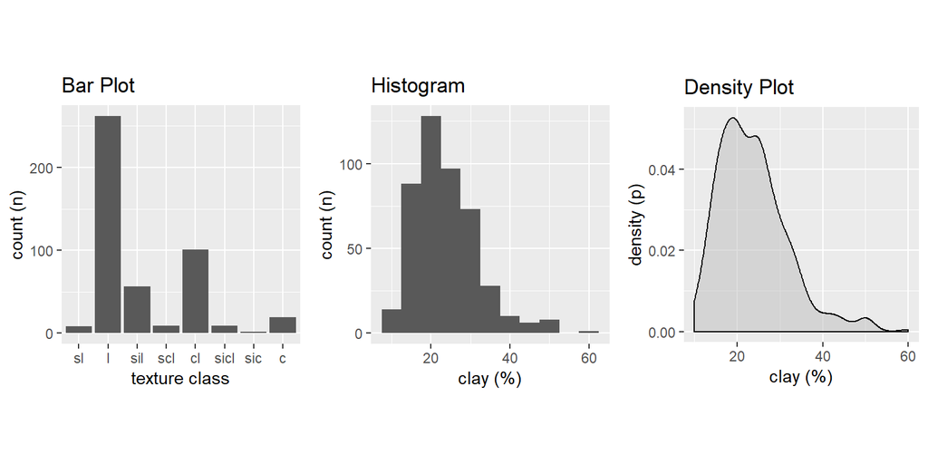

## 5.2 Bar Plot

A bar plot is a graphical display of the frequency (i.e. number of observations (count or n)), such as soil texture, that fall within a given class. It is a graphical alternative to to the `table()` function.

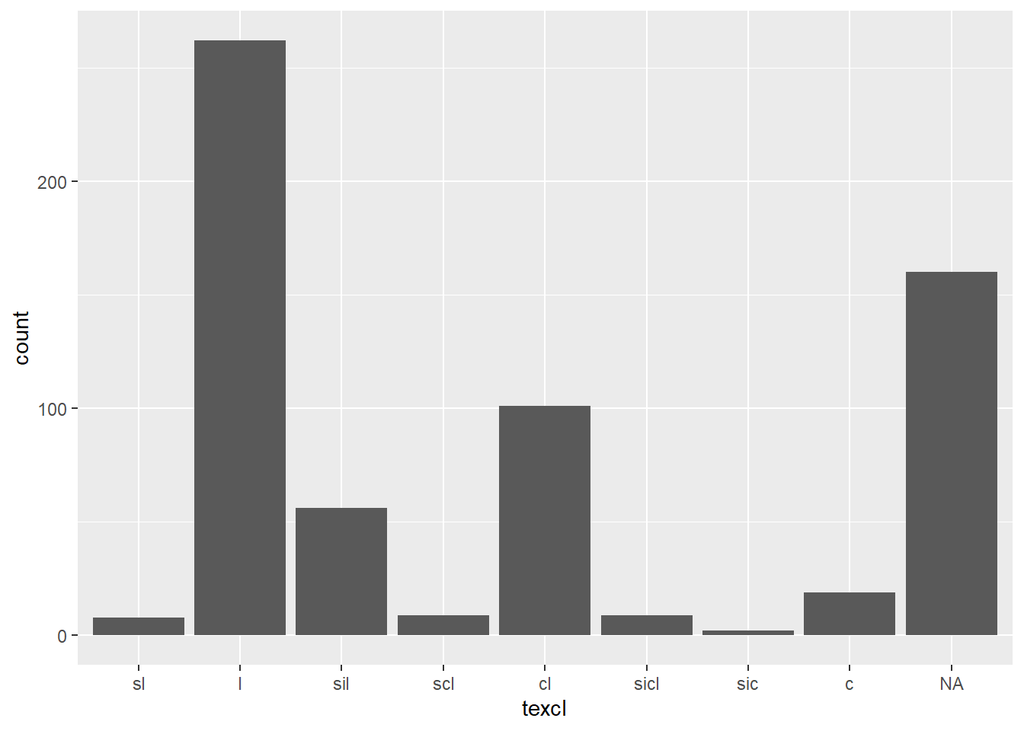

```r
library(ggplot2)

# bar plot
ggplot(h, aes(x = texcl)) +
  geom_bar()
```

## 5.3 Histogram

A histogram is similar to a bar plot, except that instead of summarizing categorical data, it categorizes a continuous variable like clay content into non-overlappying intervals for the sake of display. The number of intervals can be specified by the user, or can be automatically determined using an algorithm, such as `nclass.Sturges()`. Since histograms are dependent on the number of bins, for small datasets they’re not the best method of determining the shape of a distribution.

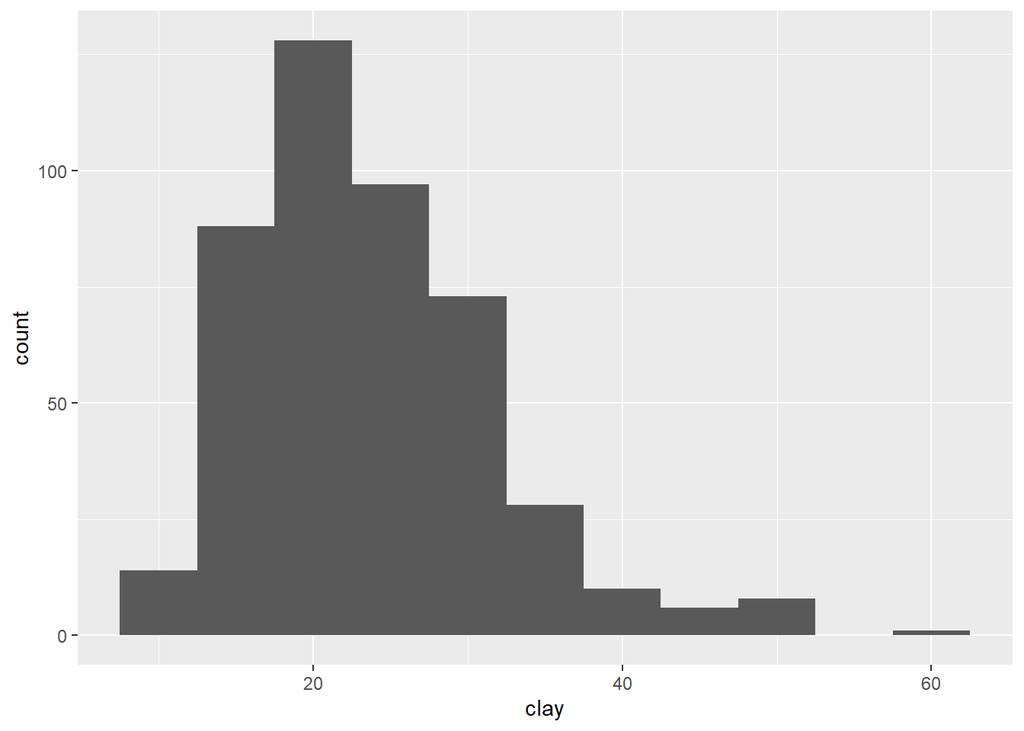

```r
ggplot(h, aes(x = clay)) +
  geom_histogram(bins = nclass.Sturges(h$clay))
```

## 5.4 Density Curve

A density estimation, also known as a Kernel density plot, generally provides a better visualization of the shape of the distribution in comparison to the histogram. Compared to the histogram where the y-axis represents the number or percent (i.e., frequency) of observations, the y-axis for the density plot represents the probability of observing any given value, such that the area under the curve equals one. One curious feature of the density curve is the hint of a two peaks (i.e. bimodal distribution?). Given that our sample includes a mixture of surface and subsurface horizons, we may have two different populations. However considering how much the two distributions overlap, it seems impractical to separate them in this instance.

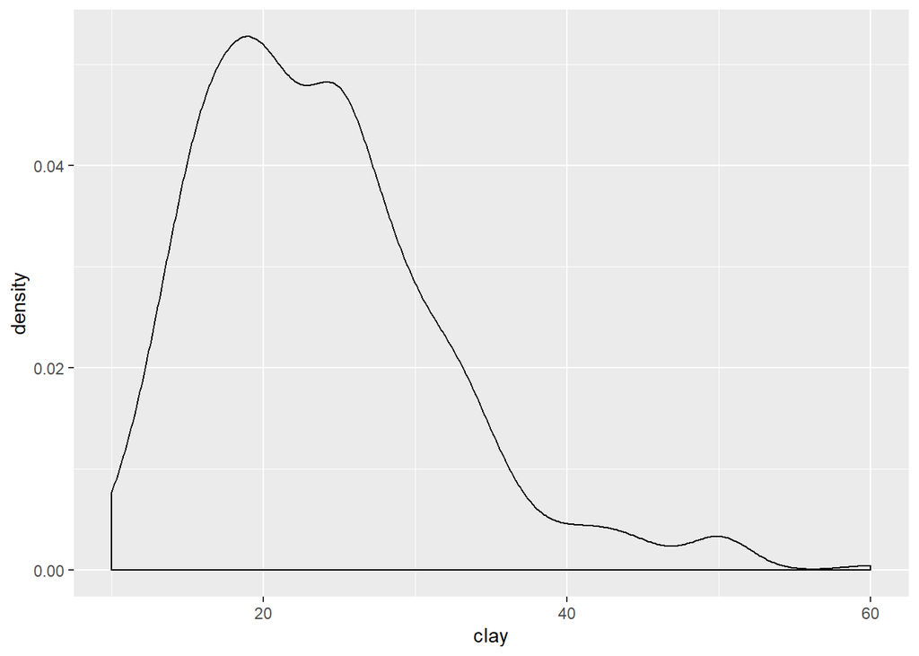

```r
ggplot(h, aes(x = clay)) +
  geom_density()
```

## 5.5 Box plots

Box plots are a graphical representation of the five number summary, depicting quartiles (i.e. the 25%, 50%, and 75% quantiles), minimum, maximum and outliers (if present). Boxplots convey the shape of the data distribution, the presence of extreme values, and the ability to compare with other variables using the same scale, providing an excellent tool for screening data, determining thresholds for variables and developing working hypotheses.

The parts of the boxplot are shown in the figure below. The “box” of the boxplot is defined as the 1st quartile, (Q1 in the figure) and the 3rd quartile, (Q3 in the figure). The median, or 2nd quartile, is the dark line in the box. The whiskers (typically) show data that is 1.5 * IQR above and below the 3rd and 1st quartile. Any data point that is beyond a whisker is considered an outlier.

That is not to say the outlier points are in error, just that they are extreme compared to the rest of the dataset. However, you may want to evaluate these points to ensure that they are correct.

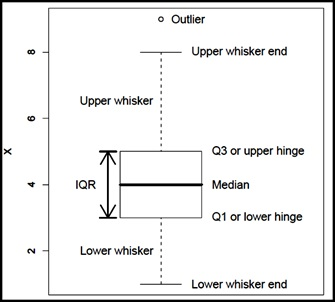

Boxplot description (Seltman, 2009)

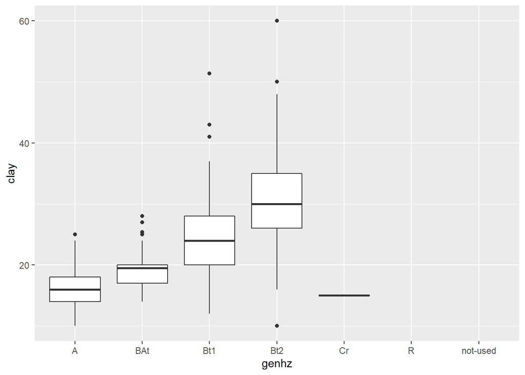

```r
ggplot(h, (aes(x = genhz, y = clay))) +
  geom_boxplot()
```

The above box plot shows a steady increase in clay content with depth. Notice the outliers in the box plots, identified by the individual circles.

## 5.6 Quantile comparison plots (QQplot)

A QQ plot is a plot of the actual data values against a normal distribution (which has a mean of 0 and standard deviation of 1).

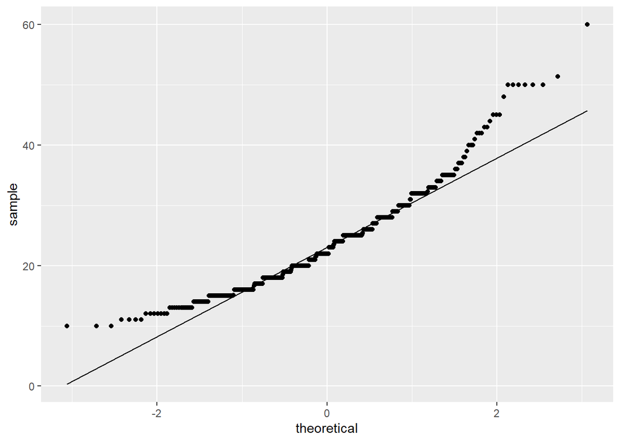

```r
# QQ Plot for Clay
ggplot(h, aes(sample = clay)) +
  geom_qq() +
  geom_qq_line()
```

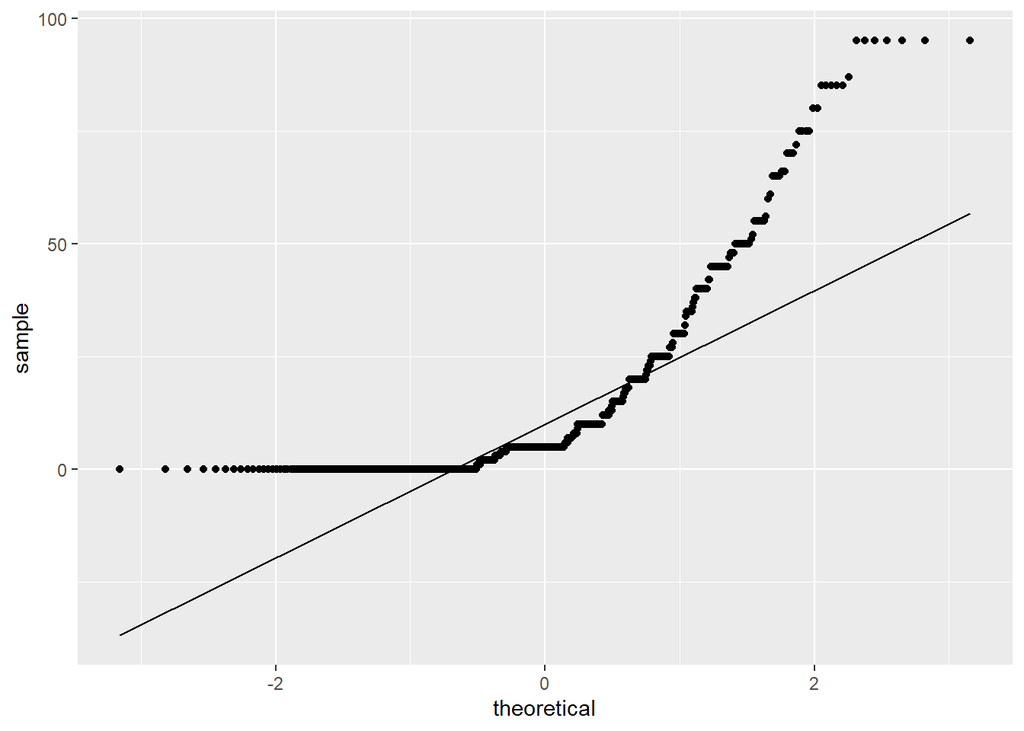

```r
# QQ Plot for Frags
ggplot(h, aes(sample = total_frags_pct)) +
  geom_qq() +
  geom_qq_line()
```

If the data set is perfectly symmetric (i.e. normal), the data points will form a straight line. Overall this plot shows that our clay example is more or less symmetric. However the second plot shows that our rock fragments are far from evenly distributed.

A more detailed explanation of QQ plots may be found on Wikipedia:  
[https://en.wikipedia.org/wiki/QQ_plot](https://en.wikipedia.org/wiki/Q%E2%80%93Q_plot)

## 5.7 The ‘Normal’ distribution

What is a normal distribution and why should you care? Many statistical methods are based on the properties of a normal distribution. Applying certain methods to data that are not normally distributed can give misleading or incorrect results. Most methods that assume normality are robust enough for all data except the very abnormal. This section is not meant to be a recipe for decision making, but more an extension of tools available to help you examine your data and proceed accordingly. The impact of normality is most commonly seen for parameters used by pedologists for documenting the ranges of a variable (i.e., Low, RV and High values). Often a rule-of thumb similar to: “two standard deviations” is used to define the low and high values of a variable. This is fine if the data are normally distributed. However, if the data are skewed, using the standard deviation as a parameter does not provide useful information of the data distribution. The quantitative measures of Kurtosis (peakedness) and Skewness (symmetry) can be used to assist in accessing normality and can be found in the [fBasics](https://cran.r-project.org/web/packages/psych/index.html) package, but [Webster (2001)](http://onlinelibrary.wiley.com/doi/10.1046/j.1365-2389.2001.00383.x/abstract) cautions against using significance tests for assessing normality. The preceding sections and chapters will demonstrate various methods to cope with alternative distributions.

A Gaussian distribution is often referred to as “Bell Curve”, and has the following properties (Lane):

1. Gaussian distributions are **symmetric** around their mean
2. The mean, median, and mode of a Gaussian distribution are **equal**
3. The area under the curve is equal to **1.0**
4. Gaussian distributions are **denser** in the center and less dense in the tails
5. Gaussian distributions are **defined** by two parameters, the mean and the standard deviation
6. **68%** of the area under the curve is within one standard deviation of the mean
7. Approximately **95%** of the area of a Gaussian distribution is within two standard deviations of the mean

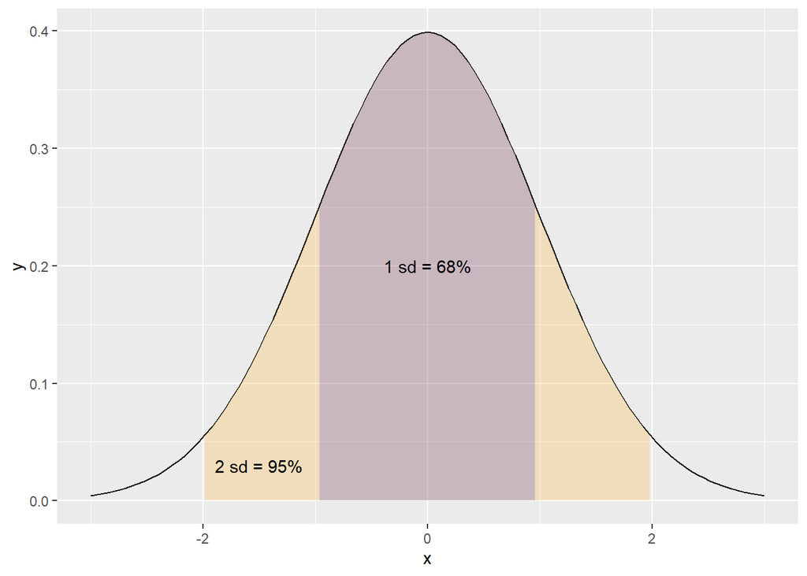

Viewing a histogram or density plot of your data provides a quick visual reference for determining normality. Distributions are typically normal, Bimodal or Skewed:

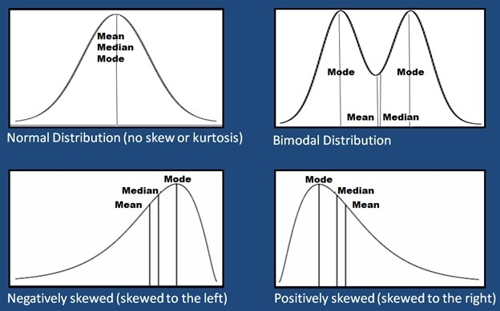

Examples of different types of distributions

Occasionally distributions are Uniform, or nearly so:

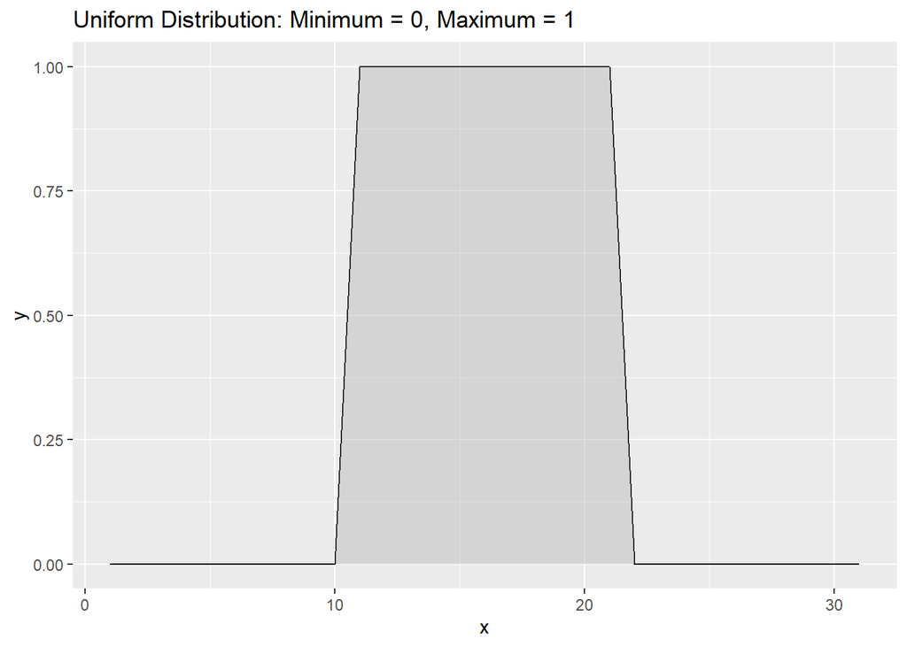

With the loafercreek dataset the mean and median for clay were only slightly different, so we can safely assume that we have a normal distribution. However many soil variables often have a non-normal distribution. For example, let’s look at graphical examination of the mean vs. median for clay and rock fragments:

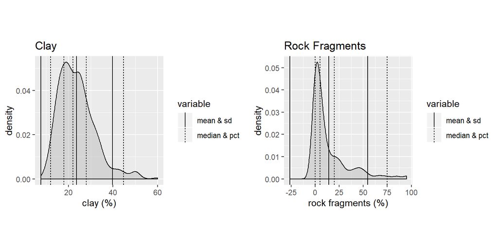

## 5.8 Scatterplots and Line Plots

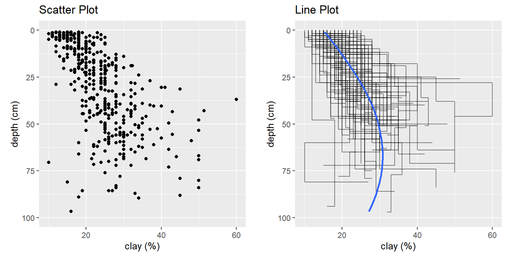

Plotting points of one ratio or interval variable against another is a scatter plot. Plots can be produced for a single or multiple pairs of variables. Many independent variables are often under consideration in soil survey work. This is especially common when GIS is used, which offers the potential to correlate soil attributes with a large variety of raster datasets.

The purpose of a scatterplot is to see how one variable relates to another. With modeling in general the goal is parsimony (i.e., simple). The goal is to determine the fewest number of variables required to explain or describe a relationship. If two variables explain the same thing, i.e., they are highly correlated, only one variable is needed. The scatterplot provides a perfect visual reference for this.

Create a basic scatter plot using the loafercreek dataset.

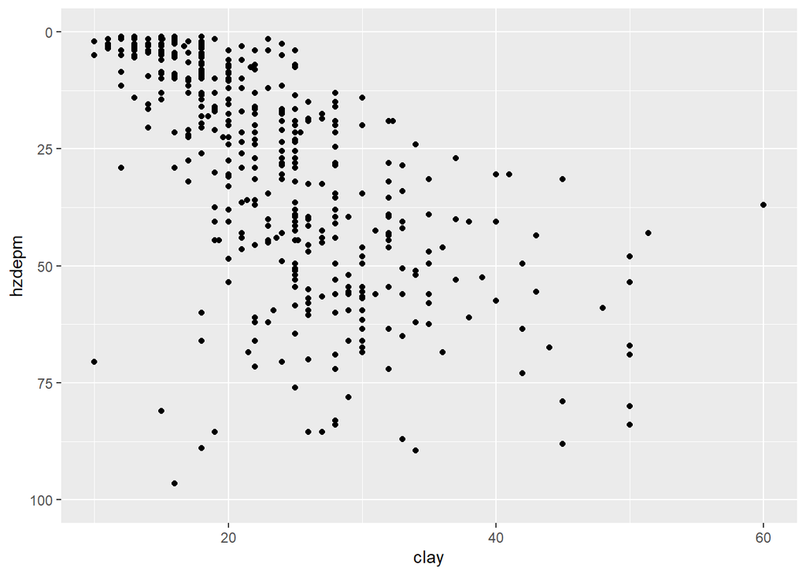

```r
# scatter plot
ggplot(h, aes(x = clay, y = hzdepm)) +
  geom_point() +
  ylim(100, 0)
```

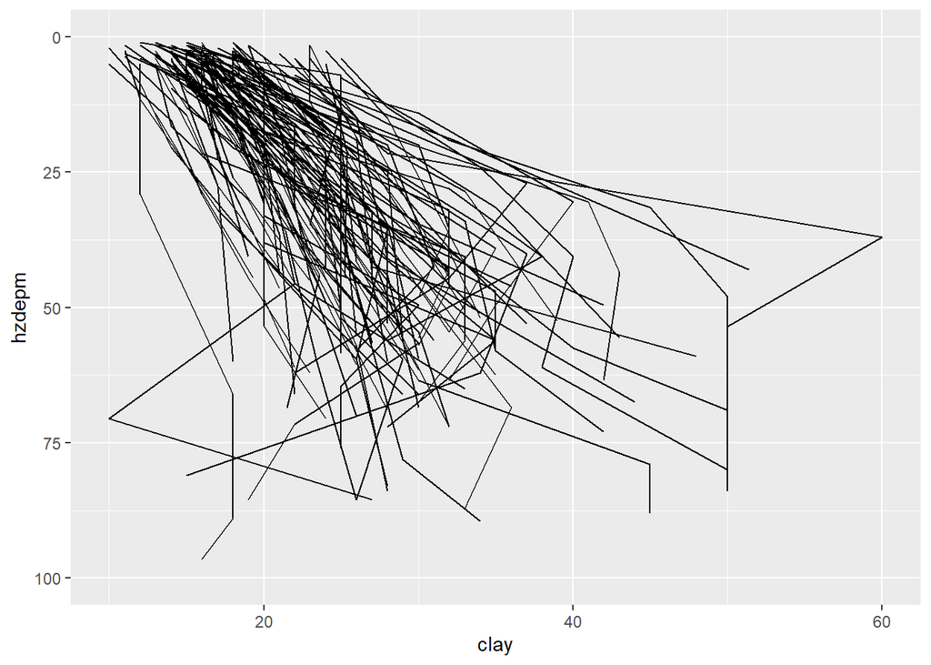

```r
# line plot
ggplot(h, aes(y = clay, x = hzdepm, group = peiid)) +
  geom_line() +
  coord_flip() +
  xlim(100, 0)
```

This plots clay on the X axis and depth on the X axis. As shown in the scatterplot above, there is a moderate correlation between these variables.

The function below produces a scatterplot matrix for all the numeric variables in the dataset. This is a good command to use for determining rough linear correlations for continuous variables.

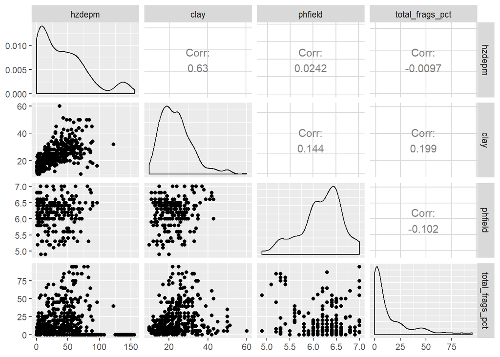

```r
# Load the GGally package
library(GGally)

# Create a scatter plot matrix
vars <- c("hzdepm", "clay", "phfield", "total_frags_pct")

ggpairs(h[vars])
```

## 5.9 3rd Dimension - Color, Shape, Size, Layers, etc…

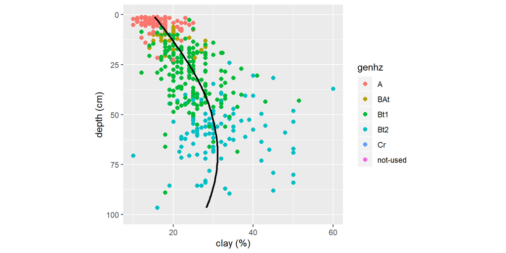

### 5.9.1 Color and Groups

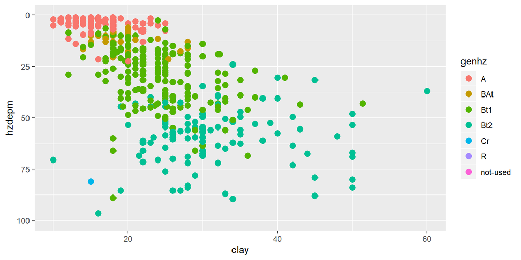

```r
# scatter plot
ggplot(h, aes(x = clay, y = hzdepm, color = genhz)) +
  geom_point(size = 3) +
  ylim(100, 0)
```

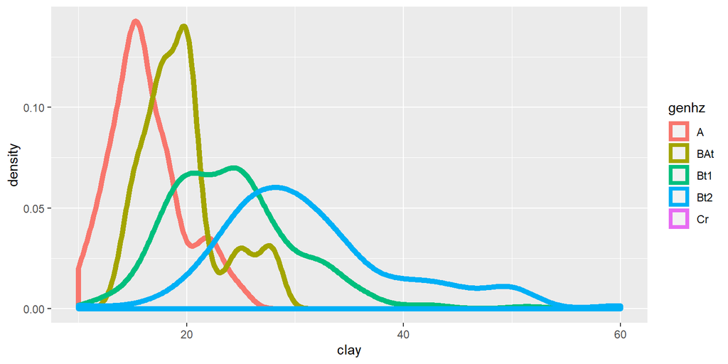

```r
# density plot
ggplot(h, aes(x = clay, color = genhz)) +
  geom_density(size = 2)
```

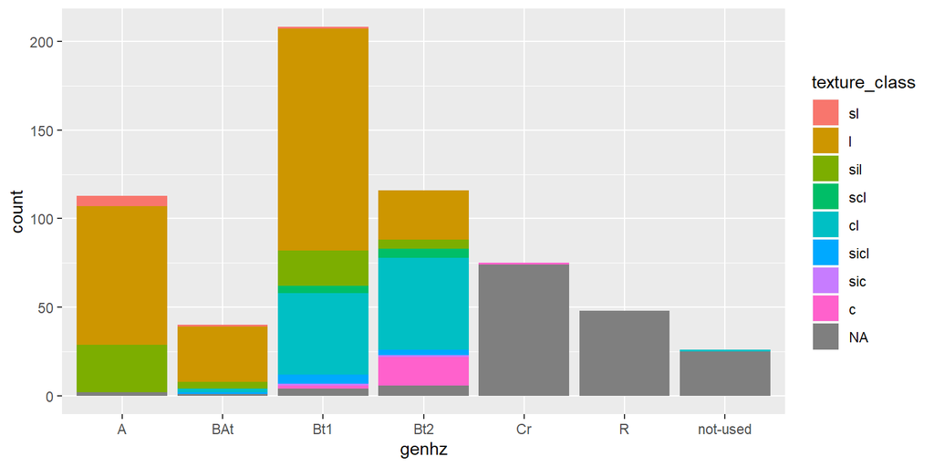

```r
# bar plot
ggplot(h, aes(x = genhz, fill = texture_class)) +
  geom_bar()
```

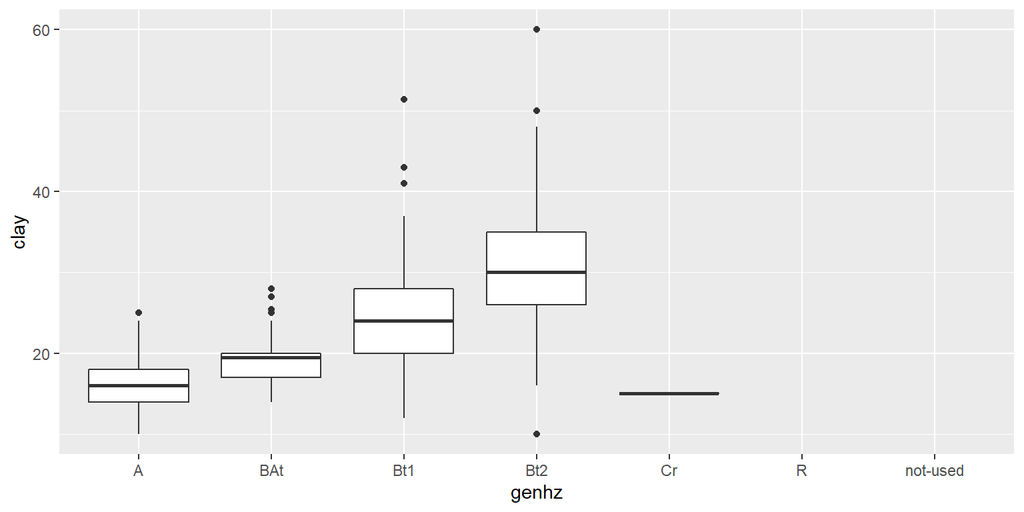

```r
# box plot
ggplot(h, aes(x = genhz, y = clay)) +
  geom_boxplot()
```

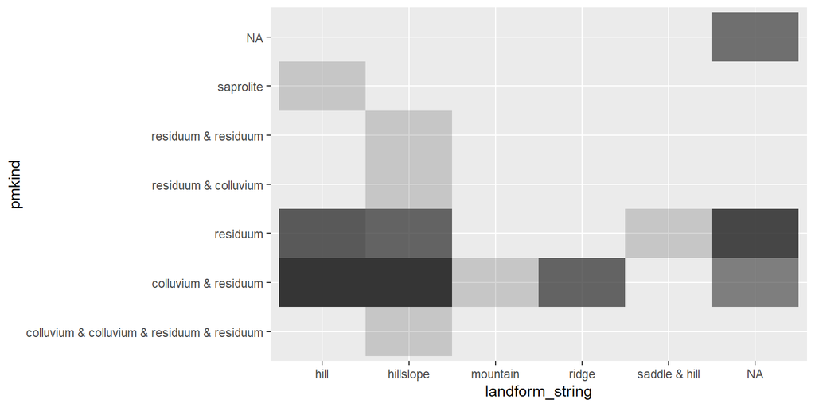

```r
# heat map (pseudo bar plot)
s <- site(loafercreek)

ggplot(s, aes(x = landform_string, y = pmkind)) +
  geom_tile(alpha = 0.2)
```

### 5.9.2 Facets - box plots

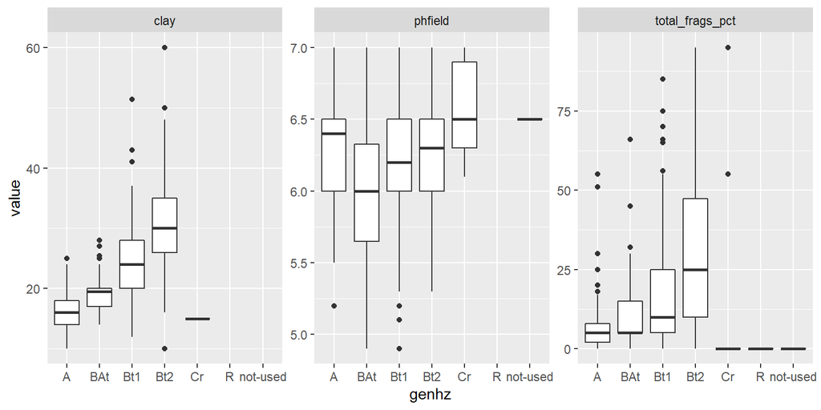

```r
# convert to long format
df <- reshape2::melt(h,
                     id.vars = c("peiid", "genhz", "hzdepm"),
                     measure.vars = c("clay", "phfield", "total_frags_pct")
                     )

ggplot(df, aes(x = genhz, y = value)) +
  geom_boxplot() +
  xlab("genhz") +
  facet_wrap(~ variable, scales = "free_y")
```

### 5.9.3 Facets - depth plots

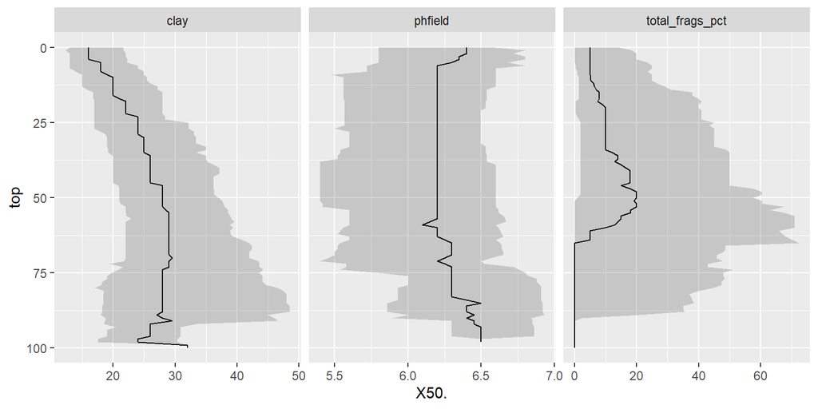

```r
library(aqp)

s <- slice(loafercreek, 0:100 ~ clay + phfield + total_frags_pct)
s <- slab(s, fm = ~ clay + phfield + total_frags_pct,
          slab.fun = function(x) quantile(x, c(0.1, 0.5, 0.9), na.rm = TRUE)
          )

ggplot(s, aes(x = top, y = X50.)) +
  geom_line() +
  geom_ribbon(aes(ymin = X10., ymax = X90., x = top), alpha = 0.2) +
  xlim(c(100, 0)) +
  coord_flip() +
  facet_wrap(~ variable, scales = "free_x")
```

# 6 Transformations

Slope aspect and pH are two common variables warranting special consideration for pedologists.

## 6.1 pH

Since **pH** has a logarithmic distribution, the use of median and quantile ranges are the [preferred](http://www.fao.org/docrep/field/003/AC175E/AC175E07.htm) measures when summarizing pH. Remember, pHs of 6 and 5 correspond to hydrogen ion concentrations of 0.000001 and 0.00001 respectively. The actual average is 5.26; -log10((0.000001 + 0.00001) / 2). If no conversions are made for pH, the mean and sd in the summary are considered the geometric mean and sd, not the arithmetic. The wider the pH range, the greater the difference between the geometric and arithmetic mean. The difference between the correct average of 5.26 and the incorrect of 5.5 is small, but proper handling of data types is a best practice.

If you have a table with pH values and wish to calculate the arithmetic mean using R, this example will work:

```r
# arithmetic mean
log10(mean(1/10^-h$phfield, na.rm = TRUE))
```

```
## [1] 6.371026
```

```r
# geometric mean
mean(h$phfield, na.rm = TRUE)
```

```
## [1] 6.18
```

## 6.2 Circular data

**Slope aspect** - requires the use of circular statistics for summarizing numerically, or graphical interpretation using circular plots. For example, if soil map units being summarized have a uniform distribution of slope aspects ranging from 335 degrees to 25 degrees, the Zonal Statistics tool in ArcGIS would return a mean of 180.

The most intuitive means available for evaluating and describing slope aspect are circular plots available with the circular package in R and the radial plot option in the [TEUI](http://www.fs.fed.us/eng/rsac/programs/teui/downloads.html) Toolkit. The circular package in R will also calculate circular statistics like mean, median, quartiles etc.

```r
library(circular)

# Extract the site table
s <- site(loafercreek)

aspect <- s$aspect_field
aspect <- circular(aspect, template="geographic", units="degrees", modulo="2pi")

summary(aspect)
```

```
##        n     Min.  1st Qu.   Median     Mean  3rd Qu.     Max.      Rho
## 101.0000  12.0000 255.0000 195.0000 199.5000 115.0000  20.0000   0.1772
##     NA's
##   5.0000
```

The numeric output is fine, but a following graphic is more revealing, which shows the dominant Southwest slope aspect.

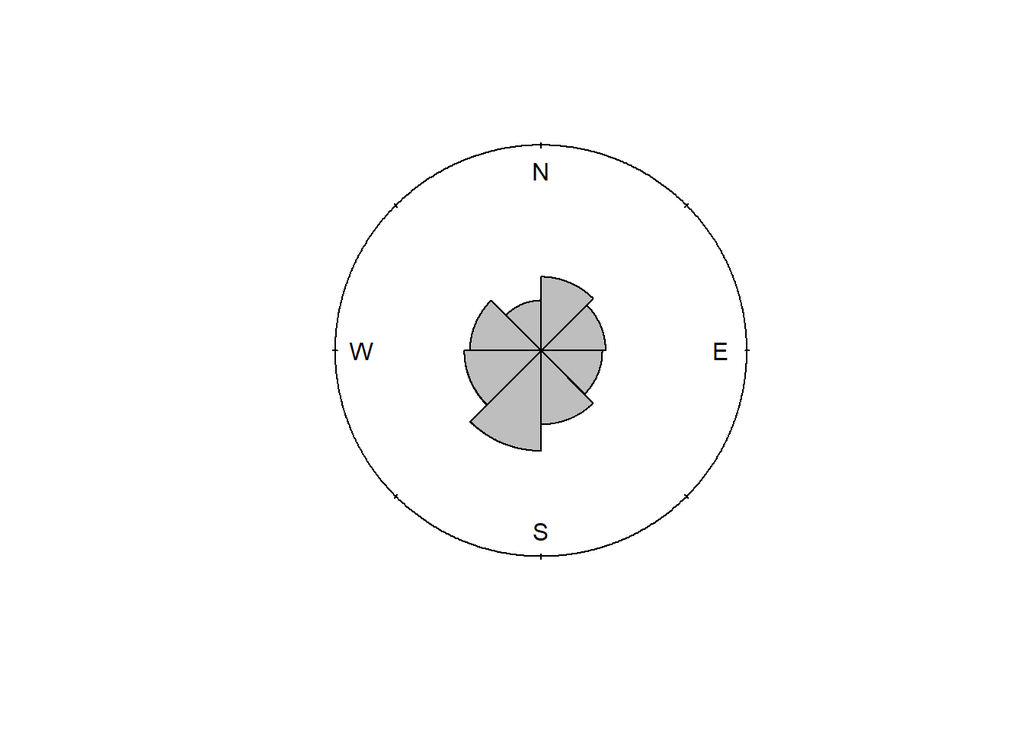

```r
rose.diag(aspect, bins = 8, col="grey")
```

# 7 Spatial EDA

## 7.1 Download Example Data

If you haven’t yet done so, please setup the sample data sets for this module.

```r
# store path as a variable, in case you want to keep it somewhere else
ch2b.data.path <- 'C:/workspace/chapter-2b'

# make a place to store chapter 2b example data
dir.create(ch2b.data.path, recursive = TRUE)

# download example data from github
# polygons
download.file('https://github.com/ncss-tech/stats_for_soil_survey/raw/master/data/chapter_2b-spatial-data/chapter-2b-mu-polygons.zip', paste0(ch2b.data.path, '/chapter-2b-mu-polygons.zip'))

# raster data
download.file('https://github.com/ncss-tech/stats_for_soil_survey/raw/master/data/chapter_2b-spatial-data/chapter-2b-PRISM.zip', paste0(ch2b.data.path, '/chapter-2b-PRISM.zip'))

# unzip
unzip(paste0(ch2b.data.path, '/chapter-2b-mu-polygons.zip'), exdir = ch2b.data.path, overwrite = TRUE)
unzip(paste0(ch2b.data.path, '/chapter-2b-PRISM.zip'), exdir = ch2b.data.path, overwrite = TRUE)
```

## 7.2 Setup R Session

Time to load some additional R packages for handling spatial data.

```r
library(aqp)
library(sp)
library(raster)
library(rgdal)
library(soilDB)
```

We will be using polygons associated with MLRAs 15 and 18 as part of this demonstration. Import these data now with `readOGR()`; recall the somewhat strange syntax.

```r
# establish path to example data
ch2b.data.path <- 'C:/workspace/chapter-2b'

# load MLRA polygons
mlra <- readOGR(dsn=ch2b.data.path, layer='mlra-18-15-AEA')
```

Next, load in the example raster data with the `raster()` function. These are 800m PRISM data that have been cropped to the extent of the MLRA 15 and 18 polygons.

```r
# mean annual air temperature, Deg C
maat <- raster(paste0(ch2b.data.path, '/MAAT.tif'))
# mean annual precipitation, mm
map <- raster(paste0(ch2b.data.path, '/MAP.tif'))
# frost-free days
ffd <- raster(paste0(ch2b.data.path, '/FFD.tif'))
# growing degree days
gdd <- raster(paste0(ch2b.data.path, '/GDD.tif'))
# percent of annual PPT as rain
rain_fraction <- raster(paste0(ch2b.data.path, '/rain_fraction.tif'))
# annual sum of monthly PPT - ET_p
ppt_eff <- raster(paste0(ch2b.data.path, '/effective_preciptitation.tif'))
```

Sometimes it is convenient to “stack” raster data that share a common grid size, extent, and coordinate reference system into a single `RasterStack` object.

```r
rs <- stack(maat, map, ffd, gdd, rain_fraction, ppt_eff)
# reset layer names
names(rs) <- c('MAAT', 'MAP', 'FFD', 'GDD', 'rain.fraction', 'eff.PPT')
```

## 7.3 Summarizing PRISM Data by Series Extent

The [`seriesExtent()`](http://ncss-tech.github.io/AQP/soilDB/series-extent.html) function from the `soilDB` package provides a simple interface to [Series Extent Explorer](https://casoilresource.lawr.ucdavis.edu/see/) data files. Note that these series extents have been generalized for rapid display at regional to continental scales. A more precise representation of “series extent” can be generated from SSURGO polygons and queried from [SDA](http://ncss-tech.github.io/AQP/soilDB/SDA-tutorial-2.html).

Get an approximate extent for the [Amador](http://casoilresource.lawr.ucdavis.edu/sde/?series=amador) soil series from [SEE](https://casoilresource.lawr.ucdavis.edu/see/#amador). See the manual page for `seriesExtent` for additional options and related functions.

```r
amador <- seriesExtent(s = 'amador')
class(amador)
```

```
## [1] "SpatialPolygonsDataFrame"
## attr(,"package")
## [1] "sp"
```

Generate 100 sampling points within the extent, using a hexagonal grid. These will be used to extract raster values from our `RasterStack` of PRISM data.

```r
s <- spsample(amador, n = 100, type = 'hexagonal')
```

For comparison, extract a single point from each SSURGO map unit delineation that contains *Amador* as a major component. This will require a query to SDA for the set of matching map unit keys (`mukey`), followed by a second request to SDA for the geometry. The `SDA_query` function is used to send arbitrary queries written in SQL to SDA, the results may be a `data.frame` or `list`, depending on the complexity of the query. The `fetchSDA_spatial` function returns map unit geometry as either polygons, polygon envelopes, or a single point per polygon and selected by `mukey` or `nationalmusym`.

```r
# result is a data.frame
mukeys <- SDA_query("
                    SELECT DISTINCT mukey
                    FROM component
                    WHERE compname = 'Amador'
                    AND majcompflag = 'Yes' ;"
)

# result is a SpatialPointsDataFrame
amador.pts <- fetchSDA_spatial(mukeys$mukey, by.col = 'mukey', method = 'point', chunk.size = 2)
```

Graphically check both methods

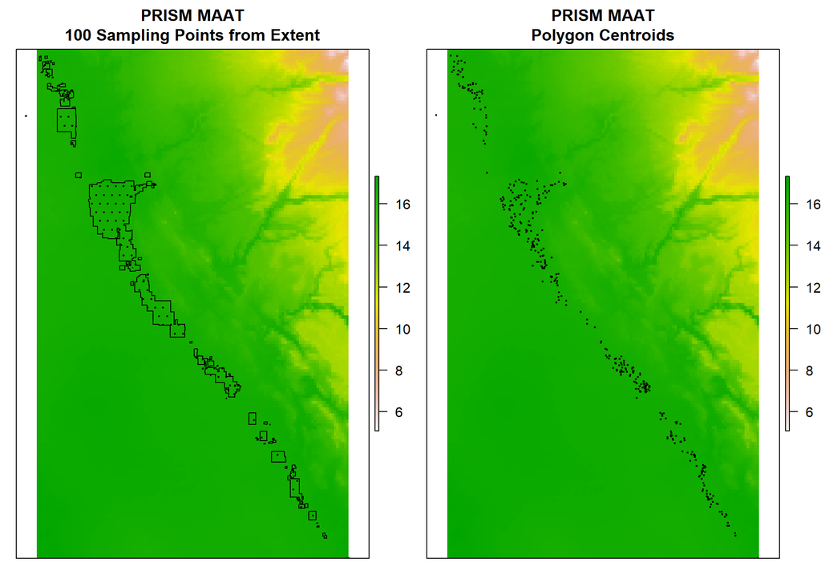

```r
# adjust margins and setup plot device for two columns
par(mar=c(1,1,3,1), mfcol=c(1,2))
# first figure
plot(maat, ext=extent(s), main='PRISM MAAT\n100 Sampling Points from Extent', axes=FALSE)
plot(amador, add=TRUE)
points(s, cex=0.25)

plot(maat, ext=extent(s), main='PRISM MAAT\nPolygon Centroids', axes=FALSE)
points(amador.pts, cex=0.25)
```

Extract PRISM data (the `RasterStack` object we made earlier) at the sampling locations (100 regularly-spaced and from MU polygon centroids) and summarize. Note that CRS transformations are automatic (when possible).

```r
# return the result as a data.frame object
e <- extract(rs, s, df=TRUE)
e.pts <- extract(rs, amador.pts, df=TRUE)

# check out the extracted data
summary(e[, -1])
```

```
##       MAAT            MAP             FFD             GDD       rain.fraction
##  Min.   :16.47   Min.   :333.0   Min.   :312.0   Min.   :2577   Min.   :99
##  1st Qu.:16.60   1st Qu.:441.8   1st Qu.:323.0   1st Qu.:2624   1st Qu.:99
##  Median :16.65   Median :484.5   Median :329.5   Median :2644   Median :99
##  Mean   :16.65   Mean   :478.5   Mean   :328.6   Mean   :2644   Mean   :99
##  3rd Qu.:16.69   3rd Qu.:534.5   3rd Qu.:335.0   3rd Qu.:2666   3rd Qu.:99
##  Max.   :17.07   Max.   :599.0   Max.   :341.0   Max.   :2764   Max.   :99
##     eff.PPT
##  Min.   :-555.2
##  1st Qu.:-417.2
##  Median :-362.8
##  Mean   :-370.7
##  3rd Qu.:-295.4
##  Max.   :-226.0
```

```r
# all pair-wise correlations
knitr::kable(cor(e[, -1]), digits = 2)
```

|  | MAAT | MAP | FFD | GDD | rain.fraction | eff.PPT |
| --- | --- | --- | --- | --- | --- | --- |
| MAAT | 1.00 | -0.48 | -0.10 | 0.76 | NA | -0.49 |
| MAP | -0.48 | 1.00 | 0.65 | -0.86 | NA | 0.99 |
| FFD | -0.10 | 0.65 | 1.00 | -0.60 | NA | 0.68 |
| GDD | 0.76 | -0.86 | -0.60 | 1.00 | NA | -0.86 |
| rain.fraction | NA | NA | NA | NA | 1 | NA |
| eff.PPT | -0.49 | 0.99 | 0.68 | -0.86 | NA | 1.00 |

Quickly compare the two sets of samples. More on this in the Sampling module.

```r
# compile results into a list
maat.comparison <- list(
  'regular samples'=e$MAAT,
  'polygon centroids'=e.pts$MAAT
  )

# number of samples per method
lapply(maat.comparison, length)
```

```
## $`regular samples`
## [1] 88
##
## $`polygon centroids`
## [1] 779
```

```r
# summary() applied by group
lapply(maat.comparison, summary)
```

```
## $`regular samples`
##    Min. 1st Qu.  Median    Mean 3rd Qu.    Max.
##   16.47   16.60   16.65   16.65   16.69   17.07
##
## $`polygon centroids`
##    Min. 1st Qu.  Median    Mean 3rd Qu.    Max.
##   16.18   16.61   16.65   16.66   16.72   17.10
```

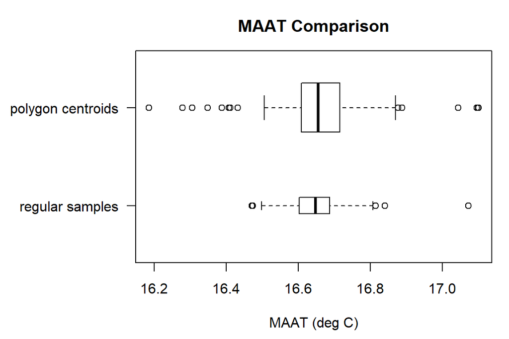

```r
# box-whisker plot
par(mar=c(4.5, 8, 3, 1), mfcol=c(1,1))
boxplot(maat.comparison, horizontal=TRUE, las=1, xlab='MAAT (deg C)',
        varwidth=TRUE, boxwex=0.5,
        main='MAAT Comparison')
```

Basic climate summaries from a standardized source (e.g. PRISM) might be a useful addition to an OSD. Think about how you could adapt this example to compare climate summaries derived from NASIS pedons to similar summaries derived from map unit polygons and generalized soil series extents.

## 7.4 Summarizing PRISM Data by MLRA Polygon

The following example is a simplified version of what is available in the [`soilReports`](https://github.com/ncss-tech/soilReports) package, reports on the [ncss-tech](https://github.com/ncss-tech/soil-pit/tree/master/reports) GitHub repository, or in the [TEUI suite of map unit summary tools](https://www.fs.fed.us/eng/rsac/programs/teui/about.html). The [*Computing GIS Summaries from Map Unit Polygons*](http://ncss-tech.github.io/AQP/sharpshootR/GIS-summary-by-MU.html) tutorial is an expanded version of this example.

Example output from the `soilReports` package:

- [summary of select CA630 map units](http://ncss-tech.github.io/example-reports/mu-comparison/CA630-mu-comparison.html)
- [summary of select MLRA polygons](http://ncss-tech.github.io/example-reports/mu-comparison/MLRA-comparison-report.html)

Efficient summary of large raster data sources can be accomplished using:

- internally-compressed raster data sources, stored on a local disk, can be in any coordinate system
- polygons stored in an equal-area or UTM coordinate system, with CRS units of meters
- [fixed-density sampling](http://ncss-tech.github.io/AQP/sharpshootR/sample-vs-population.html) of polygons
- estimation of quantiles from collected raster samples

Back to our example data. The first step is to check the MLRA polygons (`mlra`); how many features per MLRA symbol? Note that some MLRA have more than one polygon.

```r
table(mlra$MLRARSYM)
```

```
##
## 15 18
## 11  1
```

Convert polygon area from square meters to acres and summarize. Note that this will only make sense when using a projected CRS with units of meters!

```r
poly.area <- round(sapply(mlra@polygons, slot, 'area') * 0.000247105)
summary(poly.area)
```

```
##    Min. 1st Qu.  Median    Mean 3rd Qu.    Max.
##       1      43   26870 1392380  956044 8398251
```

```r
sum(poly.area)
```

```
## [1] 16708561
```

Sample each polygon at a constant sampling density of `0.001` samples per acre (1 sample for every 1,000 ac.). At this sampling density we should expect approximately 16,700 samples–more than enough for our simple example.

```r
library(sharpshootR)

# the next function requires a polygon ID: each polygon gets a unique number 1--number of polygons
mlra$pID <- 1:nrow(mlra)
s <- constantDensitySampling(mlra, n.pts.per.ac=0.001)
```

Extract MLRA symbol at sample points using the `over()` function. The result will be a `data.frame` object with all attributes from our MLRA polygons that intersect sampling points `s`.

```r
# spatial overlay: sampling points and MLRA polygons
res <- over(s, mlra)

# row / feature order is preserved, so we can directly copy
s$mlra <- res$MLRARSYM

# tabulate number of samples per MLRA
table(s$mlra)
```

```
##
##    15    18
## 11567  5156
```

Extract values from the `RasterStack` of PRISM data as a `data.frame`.

```r
# raster stack extraction at sampling points
e <- extract(rs, s, df=TRUE)

# convert sampling points from SpatialPointsDataFrame to data.frame
s.df <- as(s, 'data.frame')

# join columns from extracted values and sampling points
s.df <- cbind(s.df, e)

# check results
head(s.df)
```

```
##   pID mlra       x1      x2 ID     MAAT MAP FFD  GDD rain.fraction   eff.PPT
## 1   1   15 -2244911 1979415  1 15.51883 505 339 2351           100 -268.1914
## 2   1   15 -2242899 1979415  2 15.51962 496 334 2355            99 -272.2041
## 3   1   15 -2246923 1981427  3 15.34560 522 340 2312           100 -243.1435
## 4   1   15 -2244911 1981427  4 15.49871 554 344 2322           100 -218.0249
## 5   1   15 -2242899 1981427  5 15.56846 531 331 2374           100 -246.6457
## 6   1   15 -2250947 1983439  6 14.89704 532 349 2155           100 -210.4575
```

Summarizing multivariate data by group (MLRA) is usually much simpler after reshaping data from “wide” to “long” format.

```r
library(lattice)
library(reshape2)

# reshape from wide to long format
m <- melt(s.df, id.vars = c('mlra'), measure.vars = c('MAAT', 'MAP', 'FFD', 'GDD', 'rain.fraction', 'eff.PPT'))

# check "wide" format
head(m)
```

```
##   mlra variable    value
## 1   15     MAAT 15.51883
## 2   15     MAAT 15.51962
## 3   15     MAAT 15.34560
## 4   15     MAAT 15.49871
## 5   15     MAAT 15.56846
## 6   15     MAAT 14.89704
```

A simple tabular summary of means by MLRA and PRISM variable using `tapply()`.

```r
# tabular summary of mean values
tapply(m$value, list(m$mlra, m$variable), mean)
```

```
##        MAAT      MAP      FFD      GDD rain.fraction   eff.PPT
## 15 15.25614 586.9217 284.2352 2389.889      98.62696 -198.0893
## 18 15.66277 632.1005 273.1433 2496.216      97.24050 -192.2085
```

Lattice graphics are useful for summarizing grouped comparisons. The syntax is a little rough, but there is a lot of [documentation online](http://www.statmethods.net/advgraphs/trellis.html). [Box and whisker plots](https://en.wikipedia.org/wiki/Box_plot) are usually the first step in a graphical comparison of samples. We will go over the interpretation of these kind of figures in [chapter 4](http://ncss-tech.github.io/stats_for_soil_survey/chapters/4_exploratory_analysis/4_exploratory_analysis.html).

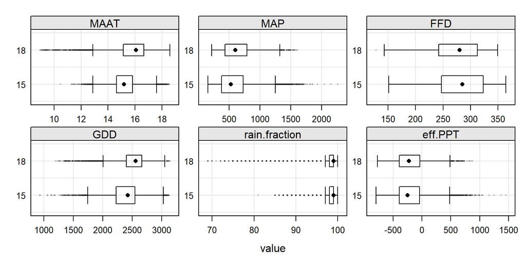

```r
tps <- list(box.rectangle=list(col='black'), box.umbrella=list(col='black', lty=1), box.dot=list(cex=0.75), plot.symbol=list(col=rgb(0.1, 0.1, 0.1, alpha = 0.25, maxColorValue = 1), cex=0.25))


bwplot(mlra ~ value | variable, data=m,                 # setup plot and data source
       as.table=TRUE,                                   # start panels in top/left corner
       varwidth=TRUE,                                   # scale width of box by number of obs
       scales=list(alternating=3, relation='free'),     # setup scales
       strip=strip.custom(bg=grey(0.9)),                # styling for strips
       par.settings=tps,                                # apply box/line/point styling
       panel=function(...) {                            # within in panel, do the following
          panel.grid(-1, -1)                            # make grid lines at all tick marks
          panel.bwplot(...)                             # make box-whisker plot
      }
)
```